# Pokemon

John Cruz

2023-03-01

## Introduction

The Serebii website provides a list, called the National Pokedex, of all the Pokemon in all the games. The table breaks down each Pokemon with a unique ID number, name, type, abilities and base stats such as attack and defense.

**Data Sources:** [Pokemon Stats](https://www.serebii.net/pokemon/nationalpokedex.shtml)

Lets determine a frequency chart of which Pokemon fall into which types they are.

## Required Libraries

```r
library(tidyverse)
library(rvest)
library(xml2)
library(janitor)
```

## Web Scrape Table into Data Frame

At first, when the table was web scraped, it brought in the values into a Data Frame, however, I quickly realized that the abilities listed multiple ones and the *rvest()* package cleaned it up by adding a space between them. This causes issues as some abilities are multiple words so to string manipulate them, I needed to account for the built-in HTML line breaks (  
). To do this, I used XML to add an intentional new line character (“\n”), so that I could be able to break them apart later.

[Using XML](https://stackoverflow.com/questions/30921626/can-rvest-keep-inline-html-tags-such-as-br-using-html-table)

```r
url <- "https://www.serebii.net/pokemon/nationalpokedex.shtml"

web_table <- read_html(url)

# use XML to account for <br> with abilities and add '\n'
xml_find_all(web_table, ".//br") |>
  xml_add_sibling("p", "\n")
xml_find_all(web_table, ".//br") |>
  xml_remove()

web_table <-
  web_table |>
  html_element('.dextable') |>
  html_table()

pokemon_stats <- as.data.frame(web_table)

knitr::kable(head(pokemon_stats))
```

| X1 | X2 | X3 | X4 | X5 | X6 | X7 | X8 | X9 | X10 | X11 | X12 |
| --- | --- | --- | --- | --- | --- | --- | --- | --- | --- | --- | --- |
| No. | Pic | Name | Type | Abilities | Base Stats | Base Stats | Base Stats | Base Stats | Base Stats | Base Stats | NA |
| No. | Pic | Name | Type | Abilities | HP | Att | Def | S.Att | S.Def | Spd | NA |
| #00001 |  |  | Bulbasaur |  | Overgrow |  |  |  |  |  |  |
| Chlorophyll | 45 | 49 | 49 | 65 | 65 | 45 |  |  |  |  |  |
|  | NA | NA | NA | NA | NA | NA | NA | NA | NA | NA | NA |
| #00002 |  |  | Ivysaur |  | Overgrow |  |  |  |  |  |  |
| Chlorophyll | 60 | 62 | 63 | 80 | 80 | 60 |  |  |  |  |  |
|  | NA | NA | NA | NA | NA | NA | NA | NA | NA | NA | NA |

## Tidy Up Data

Every other row that was brought into the Data Frame had *N/A* values. I removed these rows where if any Pokemon didn’t have a name, it was dropped. The columns between *Name* and the *Base Stats* also were shifted to the right by one column. Using a vector, I moved the columns to the appropriate alignment and followed it by using the *janitor* package to clean up column names. To account for multiple abilities, the data frame was then unpivoted into a longer format for each Pokemon.

**Note:** Pokemon types are missing and the column was dropped. It will be explained in the following section.

```r
# drop null values if Pokemon name is N/A
stats_df <-
  pokemon_stats |>
  drop_na(4)

# drop first row (duplicate header) and second column (pic)
stats_df <- stats_df[-1,-2]

# set column headers from first row and clean names
stats_df <-
  stats_df |>
  row_to_names(row_number = 1) |>
  clean_names()

# shift pokemon names, etc to left by 1 column
stats_df[c(2:10)] = stats_df[, c(3:11)]

# drop 'na' column
stats_df <-
  stats_df |>
  select(!c(na, type))

# split multiple abilities into long format based on created '\n'
stats_df <-
  stats_df |>
  separate_longer_delim(abilities, delim = "\n")

# change to pokemon number
stats_df$no <-
  parse_number(stats_df$no)

knitr::kable(head(stats_df))
```

| no | name | abilities | hp | att | def | s_att | s_def | spd |
| --- | --- | --- | --- | --- | --- | --- | --- | --- |
| 1 | Bulbasaur | Overgrow | 45 | 49 | 49 | 65 | 65 | 45 |
| 1 | Bulbasaur | Chlorophyll | 45 | 49 | 49 | 65 | 65 | 45 |
| 2 | Ivysaur | Overgrow | 60 | 62 | 63 | 80 | 80 | 60 |
| 2 | Ivysaur | Chlorophyll | 60 | 62 | 63 | 80 | 80 | 60 |
| 3 | Venusaur | Overgrow | 80 | 82 | 83 | 100 | 100 | 80 |
| 3 | Venusaur | Chlorophyll | 80 | 82 | 83 | 100 | 100 | 80 |

## Pokemon Types Missing

While working on the Data Frame, I realized the Pokemon types were missing. Looking into the HTML code, the types were not text, but images with no conventional tag name for each one. Because of this, I used another website that provides that information and web scraped similarly into another Data Frame.

```r
url <- "https://bulbapedia.bulbagarden.net/wiki/List_of_Pok%C3%A9mon_by_National_Pok%C3%A9dex_number"

web_table <- read_html(url)

# use XML to account for <br> and replace with '\n'
xml_find_all(web_table, ".//br") |>
  xml_add_sibling("p", "\n")
xml_find_all(web_table, ".//br") |>
  xml_remove()

web_table <-
  web_table |>
  html_element('body') |>
  html_table()

pokemon_types <- as.data.frame(web_table)

knitr::kable(head(pokemon_types))
```

| X1 | X2 | X3 | X4 | X5 | X6 | X7 | X8 | X9 | X10 | X11 | X12 | X13 | X14 | X15 | X16 | X17 | X18 | X19 | X20 | X21 | X22 | X23 | X24 | X25 | X26 | X27 | X28 | X29 | X30 | … |
| --- | --- | --- | --- | --- | --- | --- | --- | --- | --- | --- | --- | --- | --- | --- | --- | --- | --- | --- | --- | --- | --- | --- | --- | --- | --- | --- | --- | --- | --- | --- |
| Shortcuts |  |  |  |  |  |  |  |  |  |  |  |  |  |  |  |  |  |  |  |  |  |  |  |  |  |  |  |  |  | … |

Since each Pokemon has a unique identifier, I created the data frame to relate this ID to its types.

```r
# drop null values if Pokemon name is N/A
types_df <-
  pokemon_types |>
  drop_na(2)

# drop unnecessary columns
types_df <-
  types_df[, 1:5]

# set column headers from first row and clean names
types_df <-
  types_df |>
  row_to_names(row_number = 1) |>
  clean_names()

# change to pokemon number
types_df$ndex <-
  parse_number(types_df$ndex)

# drop N/A or zero (0) while keeping only distinct pokemon numbers
types_df <-
  types_df |>
  drop_na() |>
  filter(ndex != 0) |>
  distinct(ndex, .keep_all=TRUE)

# within same pokemon number, replace repeated types with N/A
types_df <-
  types_df |>
  mutate(type_2 = if_else(type_2 != type, type_2, NA)) |>
  select(-c(2)) |>
  rename(no = ndex)

# melt both type columns into one column
temp1 <-
  types_df |>
  select(1:3)

temp2 <-
  types_df |>
  select(1,2,4) |>
  rename(type = type_2)

types_df <-
  temp1 |>
  full_join(temp2) |>
  drop_na() |>
  select(!pokemon) |>
  arrange(no)

knitr::kable(head(types_df))
```

| no | type |
| --- | --- |
| 1 | Grass |
| 1 | Poison |
| 2 | Grass |
| 2 | Poison |
| 3 | Grass |
| 3 | Poison |

## Merge Pokemon Stats and Types Tables

Using a similar way of SQL joins, I merged the Pokemon to its types and stats.

```r
stats_types_df <-
  stats_df |>
  inner_join(types_df) |>
  relocate(type, .after = name)

knitr::kable(head(stats_types_df))
```

| no | name | type | abilities | hp | att | def | s_att | s_def | spd |
| --- | --- | --- | --- | --- | --- | --- | --- | --- | --- |
| 1 | Bulbasaur | Grass | Overgrow | 45 | 49 | 49 | 65 | 65 | 45 |
| 1 | Bulbasaur | Poison | Overgrow | 45 | 49 | 49 | 65 | 65 | 45 |
| 1 | Bulbasaur | Grass | Chlorophyll | 45 | 49 | 49 | 65 | 65 | 45 |
| 1 | Bulbasaur | Poison | Chlorophyll | 45 | 49 | 49 | 65 | 65 | 45 |
| 2 | Ivysaur | Grass | Overgrow | 60 | 62 | 63 | 80 | 80 | 60 |
| 2 | Ivysaur | Poison | Overgrow | 60 | 62 | 63 | 80 | 80 | 60 |

## Pokemon Type Frequency

The frequency chart shows us that *Water, Normal and Grass* types are the most common among all the Pokemon. One caveat to point out, is that a Pokemon could have up to two different types. This means that a Pokemon can appear twice in different categories as a result in here.

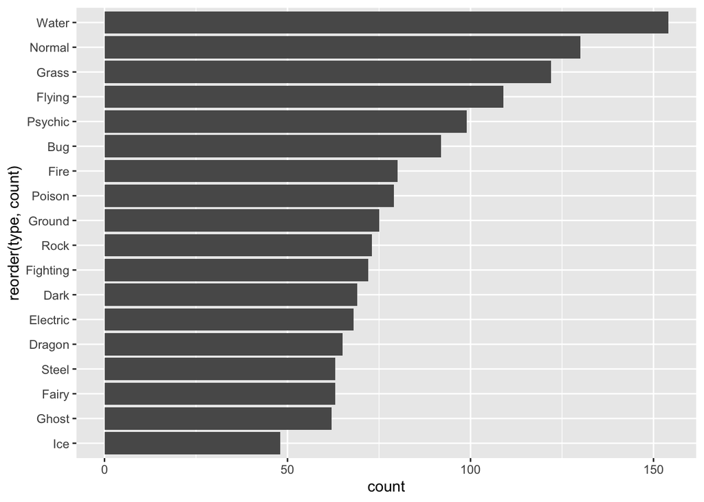

```r
grouped_type <-
  stats_types_df |>
  distinct(name, type) |>
  group_by(type) |>
  summarise(count = n()) |>
    arrange(desc(count))

grouped_type |>
  ggplot(aes(x = count, y = reorder(type, count))) +
  geom_bar(stat = 'identity')
```

```r
knitr::kable(grouped_type)
```

| type | count |
| --- | --- |
| Water | 154 |
| Normal | 130 |
| Grass | 122 |
| Flying | 109 |
| Psychic | 99 |
| Bug | 92 |
| Fire | 80 |
| Poison | 79 |
| Ground | 75 |
| Rock | 73 |
| Fighting | 72 |
| Dark | 69 |
| Electric | 68 |
| Dragon | 65 |
| Fairy | 63 |
| Steel | 63 |
| Ghost | 62 |
| Ice | 48 |